# Investing in infants: the lasting effects of cash transfers to new families

By Andrew Barr, Jonathan Eggleston, Alexander A. Smith

Author

Seiro Ito

## 1 ECD Long-run effects

- Much affirmative evidence of health and education (in-kind) interventions.
- Cash intervention impacts are little known.
  - Food stamps are different from cash (Hoynes, Schanzenbach, and Almond 2016; Bailey et al. 2023).
  - Lottery cash distributions are given at older children, results are mixed (Akee et al. 2010; Cesarini et al. 2016).

## 2 Data

**IRS1040 data at U.S. Census**

- Main tax form used to file a U.S. individual income tax return
- Every filer
- Years: 1979, 1984, 1989, 1994-95, 1998-2018
- Various incomes, dependents (Social Security Numbers)

**Social Security Administration Numident File**

- Every person born after 1969
- Date of birth, sex, state of birth
  - Gives: Size of cash transfer in early childhood, family composition
- $\pm 1$ month of Jan 1, 1982, 1986, 1992

**North Carolina Education Data**

#### How data sets are combined

- IRS1040: Parent-dependents linkage
  - Child’s incomes in 23-25, 26-28, 29-31, 32-34 (individual+spouse, 3-year averages)
- IRS1040+NumidentFile: Date of birth of dependent → Pre-birth parental incomes → Pre-birth adjusted gross income (AGI) → EITC amount
- Use 1979 incomes (in 1980 tax record) to predict 1980 AGI → Pre-birth AGI for a Jan 1981 born child
- Predicted AGI using lagged incomes
  - Attenuation bias
  - Less concerns of endogeneity (parental ability correlates with AGI, chance of birth date selection)
- Create an index: Weighted normalised $z$ scores or each outcome $k=\sum\limits_{k}w_{k}\frac{x_{k, treated}-\hat{\mu}_{x_{k, control}}}{\hat{\sigma}_{x_{k, control}}}$ (Kling, Liebman, and Katz 2007)

## 3 Empirical strategy

Birthday RDD (Schulkind and Shapiro 2014)

- Dec 31: Eligible in +1 day
- Jan 1: Eligible in +1 year

ITT effects: Some eligible (mostly Hispanics, African Americans) do not apply

Strength

- Pure cash transfer impacts, not “coupled with changes to work incentives”

Concerns

1. Some may deliver earlier, confirmed by (Buckles and Hungerman 2013; with a c-section, Schulkind and Shapiro 2014)
   - No jump in density for firstborns around new year (Fig II)
   - Balance in covariates (Tab II)
   - “Donut-hole” RDD: Drop observations within $\pm$ 8 days of Jan 1
2. Discontinuity in other variables
   - School year begins near Jan 1 in some states, drop these states
   - Larger tax benefits in later years: Expect larger impacts in later years

$$\begin{equation}
Y_{it}=\beta_{0}+\beta_{1}\mathcal 1[z_{i}<0]+\beta_{2}z_{i}+\beta_{3}\mathcal 1[z_{i}<0]z_{i}+\theta_{t}+\epsilon_{it}.
\tag{2}
\end{equation}$$

```r
library(knitr)
desc <- matrix(c(
    "$z_{i}$",  "Days before Jan 1.",
    "$\\mathcal 1[z_{i}<0]$", "Treatment assignment.",
    "$\\beta_{1}$", "Main interest."
  ), byrow = T, ncol = 2)
kableExtra::kbl(desc, align = c("r", "l"), label = NA, caption = NA,
  table.attr = list(style="font-size:26px; color:red;"), format = "markdown")
```

| $z_{i}$ | Days before Jan 1. |
| --- | --- |
| $\mathcal 1[z_{i}<0]$ | Treatment assignment. |
| $\beta_{1}$ | Main interest. |

## 4 Results

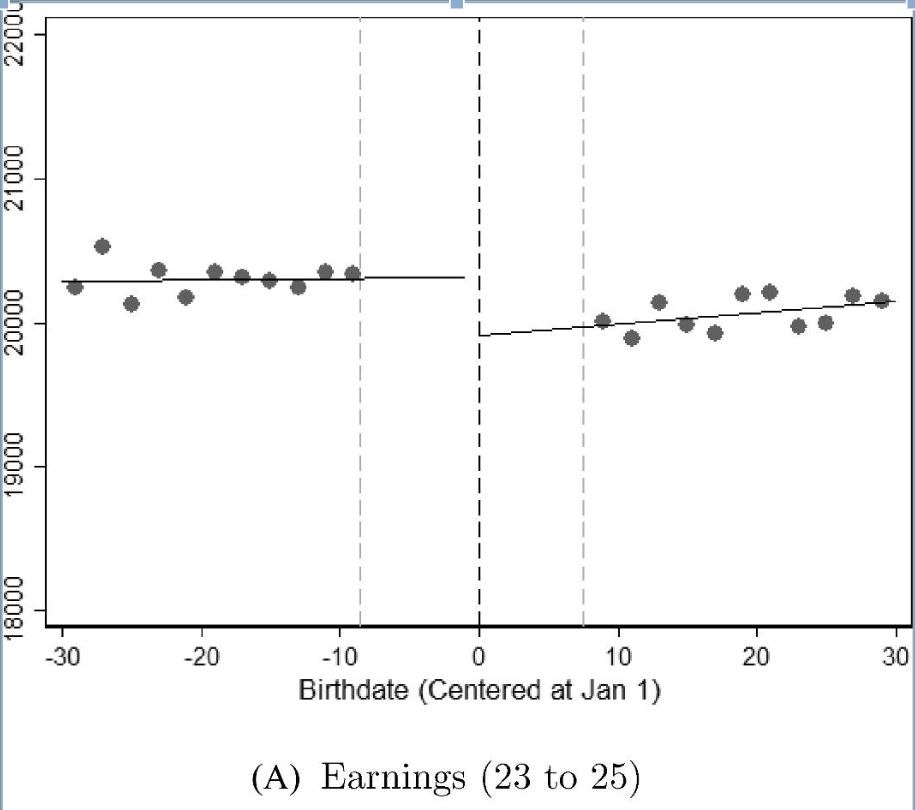

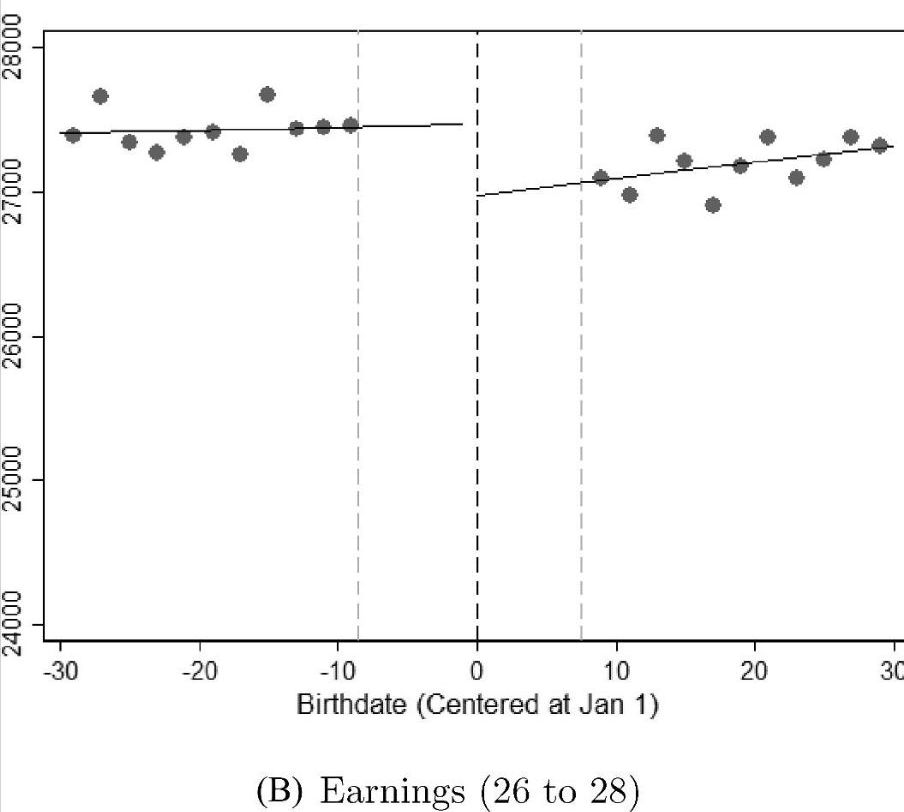

Figure 1: Impacts on child incomes in adulthood

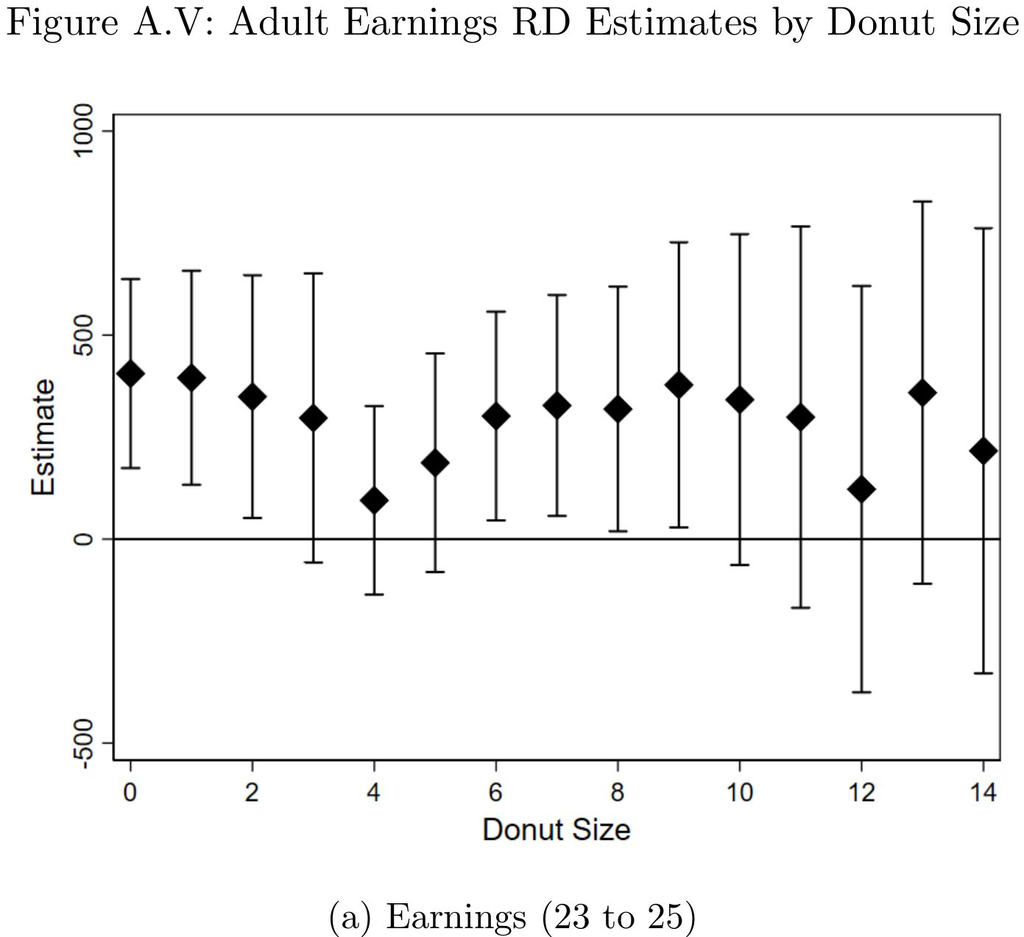

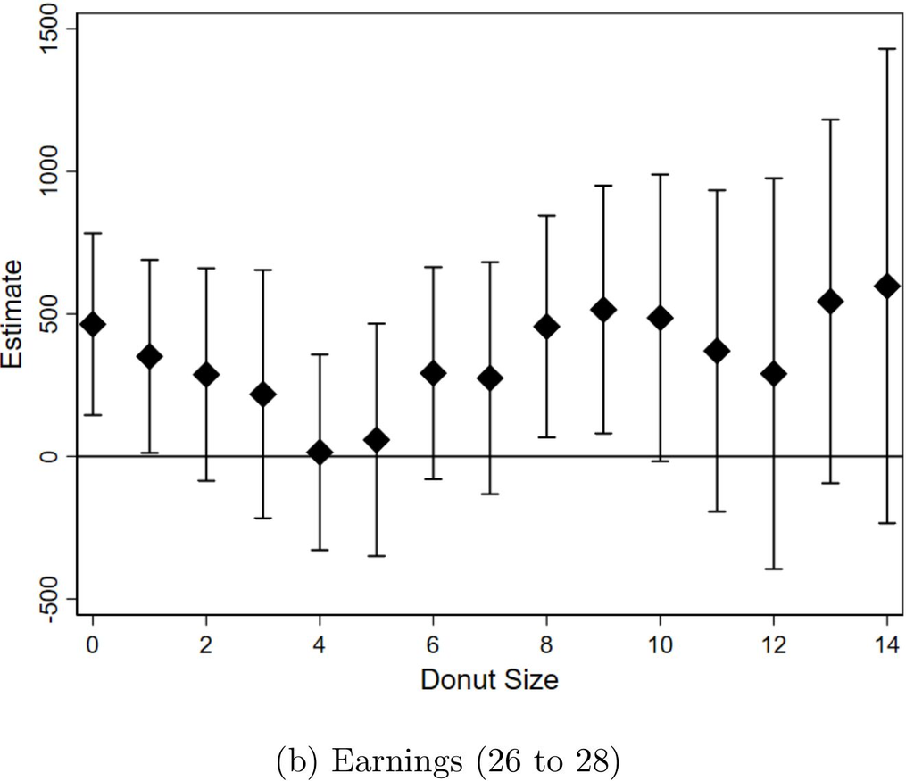

Figure 2: Impacts by donut size

- Parents may shift delivery by 4 days (just after Christmas)…
- Later cohorts have larger impacts (Tab IV)
- Much smaller impacts for nonfirstborn ← transfer is $306 vs. $1,291 (Tab A.VI)
- Smaller income impacts for women, because they are more likely to file jointly with spouse, and their income shares are lower (Fig IV)
- Larger impacts in later years (Fig V) ← more generous transfers

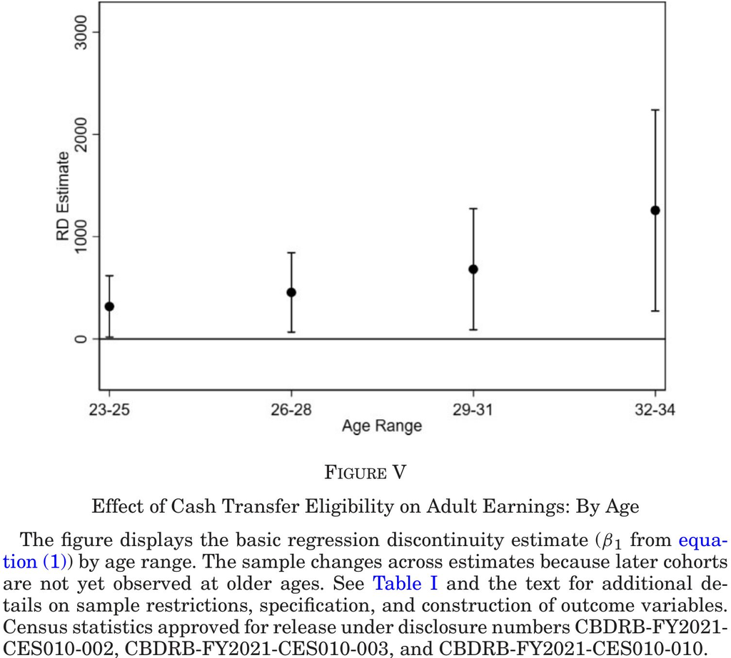

- $+319 (23-25), $+456 (26-28), larger at 29+
- Earnings by 26 is predictive of future earnings (Haider and Solon 2006; Chetty et al. 2011)

## 5 Mechanism: Parents and family environment

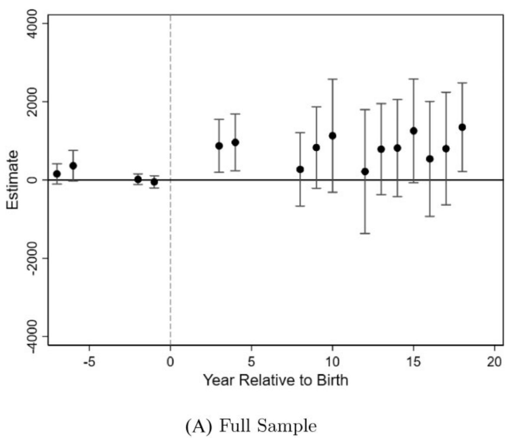

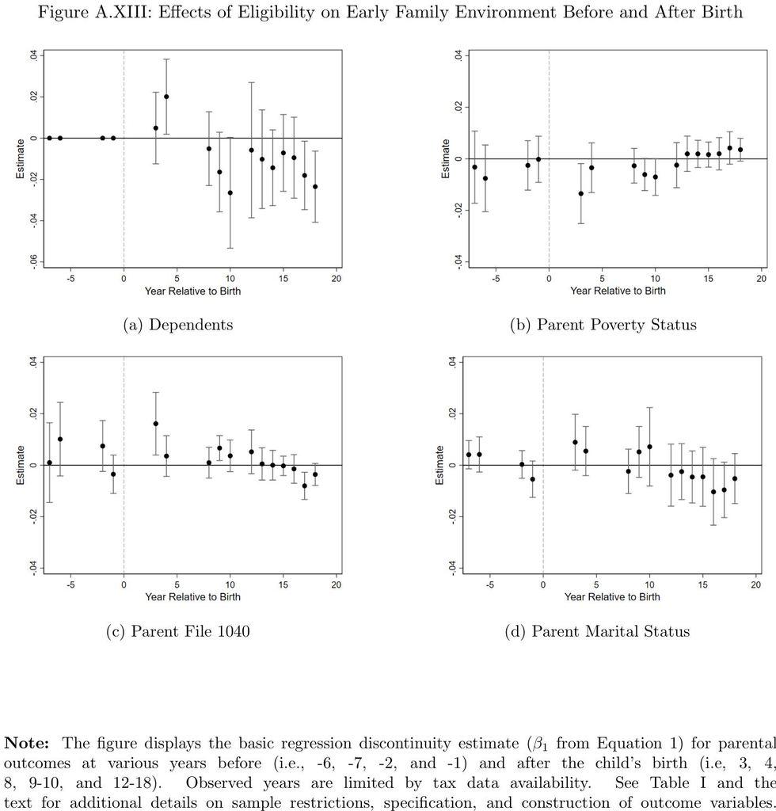

## 6 Mechanism: Child human capital

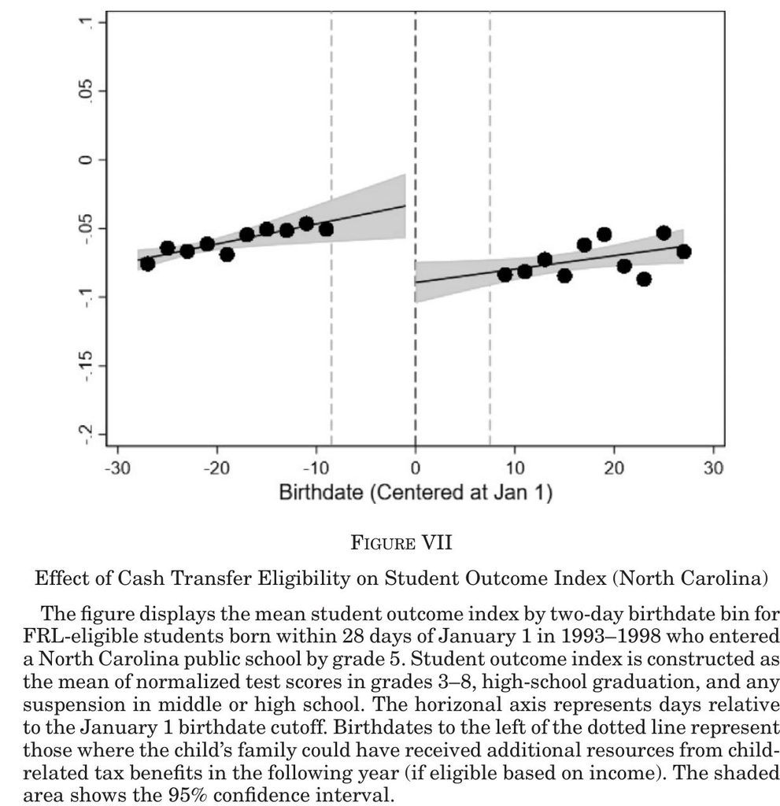

Outcome index↑ by .03$\sigma$ per $1000 EITC

- Test scores grades 3-8↑ by .037$\sigma$
- HS graduation↑ by .02$\sigma$
- Suspension↓ by .02$\sigma$

Robust to donut size and RDD bandwidth (Tab A12)

See also Tab VIII, Tab A13

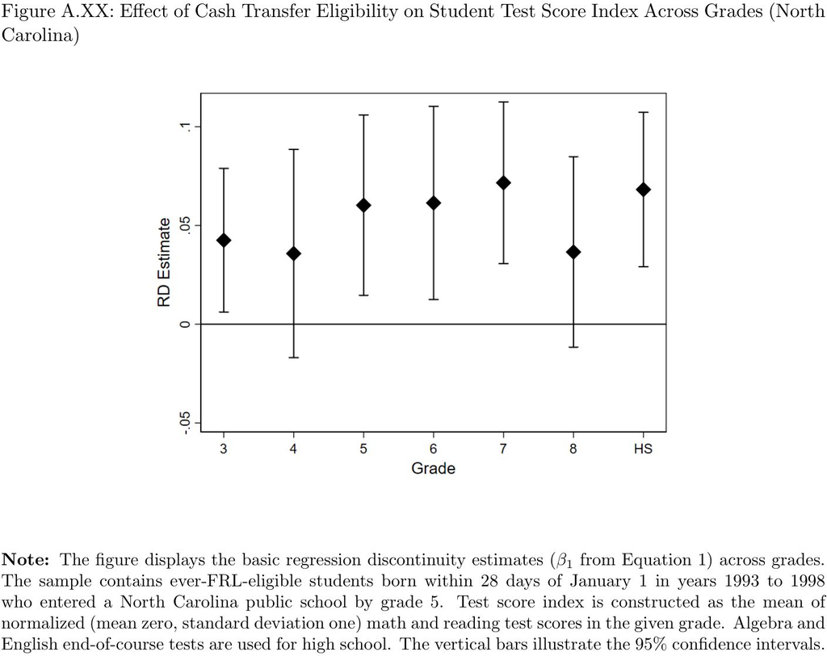

- Test scores impacts do not fade
- Suggests human capital channel at play
- Little gender difference
  - Due probably to less noise in outcomes than tax filing
- Exam score $\sigma$↑ ⇒ $2500↑ at age 28 per year (Chetty, Friedman, and Rockoff 2014)
- .037$\sigma$ (per $1000)$\times$ $2500=$92 per year per $1000 spent
  - 9.2% is pretty high…
- “(C)ould entirely account for our observed wage effects … $353 per $1000” (?)

## 7 Conclusions

- Long lasting positive impacts of liquidity increase within 12 months after the birth of firstborns
  - Adult incomes, test scores, behavioral problems, HS graduation
  - Not evidence for later transfers or non-firstborns
- NPV of tax receipts from added incomes > initial transfer
- From Sec IV.B: Impact as % earnings per $1000 spent
  - Food stamps: .3% to 1%
  - Perry: Under 1%
  - EITC: 1% to 2%
- Previous studies on casino wins, lottery, adoption are on wealthier familes, so their impacts are small

## 8 感想

- 成人所得への効果? かねてからの疑問に答える画期的な研究
- さらに、NCデータを使って人的資本経由というメカニズムもある程度明らかにした
- 現金を親に渡すと子どもに使わない等の懸念が伝統的にあるが、現金でも結果が出てます、と示した
- 現金移転の方が効率的なので、保健や教育などで現物移転ばかり強調しすぎない方が良いかも
  - 現金移転は教育に効果、現金で自動車を買うと非難されそう
- 外的妥当性: EITC無知層(ヒスパニックやアフリカ系)、途上国
  - 親の知識水準に依存しそう

#### References

Akee, Randall K. Q., William E. Copeland, Gordon Keeler, Adrian Angold, and E. Jane Costello. 2010. “Parents’ Incomes and Children’s Outcomes: A Quasi-Experiment Using Transfer Payments from Casino Profits.” *American Economic Journal: Applied Economics* 2 (1): 86–115. https://doi.org/10.1257/app.2.1.86.

Bailey, Martha J., Hilary Hoynes, Maya Rossin-Slater, and Reed Walker. 2023. “Is the social safety net a long-term investment? Large-scale evidence from the food stamps program.” *The Review of Economic Studies* 91 (3): 1291–1330. https://doi.org/10.1093/restud/rdad063.

Buckles, Kasey S., and Daniel M. Hungerman. 2013. “Season of birth and later outcomes: Old questions, new answers.” *The Review of Economics and Statistics* 95 (3): 711–24. https://doi.org/10.1162/REST_a_00314.

Cesarini, David, Erik Lindqvist, Robert Östling, and Björn Wallace. 2016. “Wealth, health, and child development: Evidence from administrative data on Swedish lottery players.” *Quarterly Journal of Economics* 131 (2): 687–738. https://doi.org/10.1093/qje/qjw001.

Chetty, Raj, John N. Friedman, Nathaniel Hilger, Emmanuel Saez, Diane Whitmore Schanzenbach, and Danny Yagan. 2011.“ How Does Your Kindergarten Classroom Affect Your Earnings? Evidence from Project Star *.” *The Quarterly Journal of Economics* 126 (4): 1593–1660. https://doi.org/10.1093/qje/qjr041.

Chetty, Raj, John N. Friedman, and Jonah E. Rockoff. 2014. “Measuring the Impacts of Teachers II: Teacher Value-Added and Student Outcomes in Adulthood.” *American Economic Review* 104 (9): 2633–79. https://doi.org/10.1257/aer.104.9.2633.

Evans, William N., and Craig L. Garthwaite. 2014. “Giving Mom a Break: The Impact of Higher EITC Payments on Maternal Health.” *American Economic Journal: Economic Policy* 6 (2): 258–90. https://doi.org/10.1257/pol.6.2.258.

Haider, Steven, and Gary Solon. 2006. “Life-Cycle Variation in the Association Between Current and Lifetime Earnings.” *American Economic Review* 96 (4): 1308–20. https://doi.org/10.1257/aer.96.4.1308.

Hoynes, Hilary, Diane Whitmore Schanzenbach, and Douglas Almond. 2016. “Long-Run Impacts of Childhood Access to the Safety Net.” *American Economic Review* 106 (4): 903–34.

Kling, Jeffrey R., Jeffrey B. Liebman, and Lawrence F. Katz. 2007. “Experimental Analysis of Neighborhood Effects.” *Econometrica* 75 (1): 83–119. https://doi.org/10.1111/j.1468-0262.2007.00733.x.

Milligan, Kevin, and Mark Stabile. 2011. “Do Child Tax Benefits Affect the Well-Being of Children? Evidence from Canadian Child Benefit Expansions.” *American Economic Journal: Economic Policy* 3 (3): 175–205. https://doi.org/10.1257/pol.3.3.175.

Schmidt, Lucie, Lara Shore-Sheppard, and Tara Watson. 2023. “The Effect of Safety Net Generosity on Maternal Mental Health and Risky Health Behaviors.” *Journal of Policy Analysis and Management* 42 (3): 706–36. https://doi.org/10.1002/pam.22481.

Schulkind, Lisa, and Teny Maghakian Shapiro. 2014. “What a Difference a Day Makes: Quantifying the Effects of Birth Timing Manipulation on Infant Health.” *Journal of Health Economics* 33: 139–58. https://doi.org/10.1016/j.jhealeco.2013.11.003.